# 260-2016-12-07

2016-12-07 09:57:10

## Announcements

- Review for Exam 4 on Friday
- Exam 4, Monday 10:10a

## Today's Topics

- LTP
- Patient HM
- Alzheimer's Disease
- Hippocampus

## LTP signaling

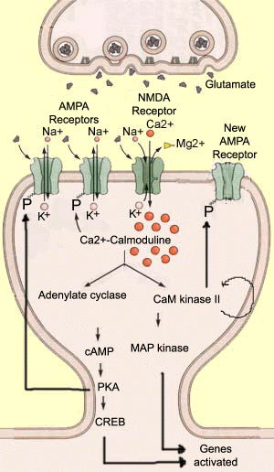

http://thebrain.mcgill.ca/flash/a/a_07/a_07_m/a_07_m_tra/a_07_m_tra.html

## Dimensions of stored info

- Memory of what?
  - Facts/events/places vs. skills
- Memory of when?
  - Immediate vs. distant past
- Memory for how long?
  - Seconds vs. years

## Memory systems in the brain

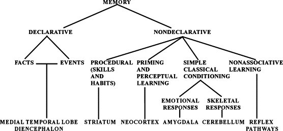

[(Squire 2004)](http://dx.doi.org/10.1016/j.nlm.2004.06.005)

## Summary thus far

- Learning and memory involve changes in neural firing, circuitry
- Hebbian learning a type of associative learning
- NMDA receptor as coincidence detector
  - Molecular basis of one form of long-term potentiation (LTP)
- Different types of information stored in different brain systems

## Disorders of memory

## [Patient HM](http://www.pbs.org/wgbh/nova/body/corkin-hm-memory.html) (Henry G. Molaison)

- Intractable/untreatable epilepsy
- Bilateral resection of medial temporal lobe (1953)
- Epilepsy now treatable
- But, memory impaired
- Lived until 2008

## Brenda Milner tells the story

[video not shown]

## HM's surgery

[figure not shown]

## Amnesia

- Acquired loss of memory
- ≠ normal forgetting
- Note: computers don't forget

## HM's amnesia

- **Retrograde amnesia**
  - Can’t remember 10 yrs before operation
  - Distant past better than more recent
- Severe, global **anterograde amnesia**
  - Impaired learning of new facts, events, people
- But, skills (mirror learning) intact

## Types of amnesia

- Retrograde ('backwards' in time)
  - Damage to information acquired pre-injury
  - Temporally graded
- Anterograde ('forward' in time)
  - Damage to information acquired/experienced post-injury

## What it's like

*Every day is alone in itself, whatever enjoyment I’ve had, and whatever sorrow I’ve had…Right now, I’m wondering, have I done or said anything amiss? You see at this moment, everything looks clear to me, but what happened just before? That’s what worries me. It’s like waking from a dream. I just don’t remember.*

## What it's like

[video not shown]

## Other causes of amnesia

- Disease
  - Alzheimer’s, herpes virus
- [Korsakoff’s syndrome](https://en.wikipedia.org/wiki/Korsakoff%27s_syndrome)
  - Result of severe alcoholism
  - Impairs medial thalamus & mammillary bodies

## Patient NA

- Fencing accident
- Damage to medial thalamus
- Anterograde + graded retrograde amnesia
- Are thalamus & medial temporal region connected?

## Patient NA

[video not shown]

## Spared skills in amnesia

- Skill-learning
- Mirror-reading, writing
- Short-term memory
- “Cognitive” skills
- Priming

## What does amnesia tell us?

- Long-term memory for facts, events, people
- ≠ Short-term memory
- ≠ Long-term memory for “skills”
- Separate memory systems in the brain?

## Memory systems in the brain

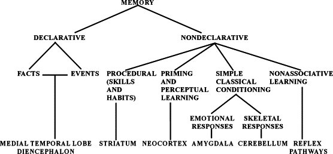

[(Squire 2004)](http://dx.doi.org/10.1016/j.nlm.2004.06.005)

## Alzheimer's Disease (AD)

- Chronic, neurodegenerative disease affecting ~5 M Americans
- Cognitive dysfunction (memory loss, language difficulties, planning, coordination)
- Psychiatric symptoms and behavioral disturbances
- Difficulties with daily living
- [(Burns and Iliffe 2009)](http://doi.org/10.1136/bmj.b158)

## AD progression

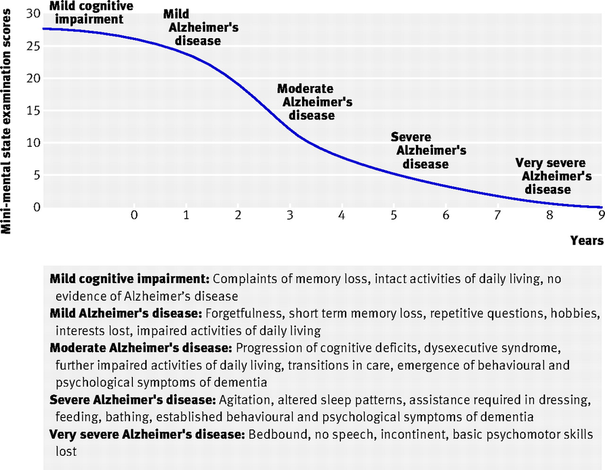

[(Burns and Iliffe 2009)](http://doi.org/10.1136/bmj.b158)

## AD

- Post-mortem exams show beta amyloid plaques and neurofibrillary tangles

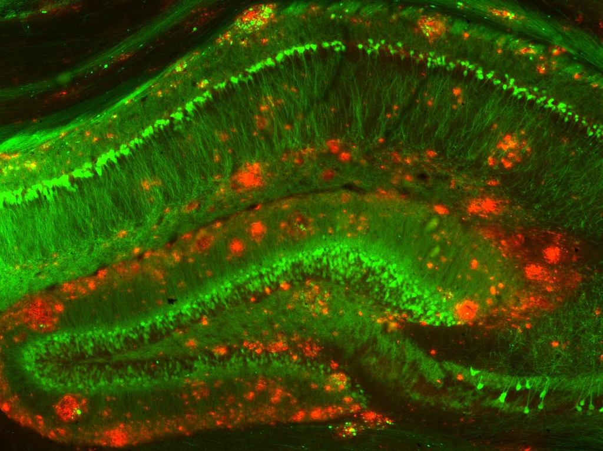

## AD

- Treatments include
  - Acetylcholinesterase (AChE) inhibitors (e.g. Aricept)
  - Glutamatergic (NMDA) partial antagonists (e.g., Memantine)

## New hope for treatment, [(Kaufman et al. 2015)](http://doi.org/10.1002/ana.24394)

[figure not shown]

## Hippocampus

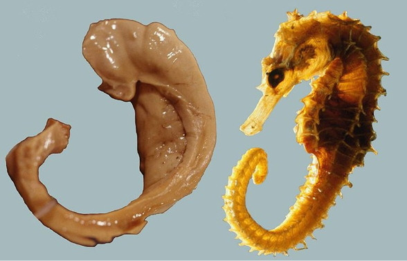

https://upload.wikimedia.org/wikipedia/commons/5/5b/Hippocampus_and_seahorse_cropped.JPG

## Hippocampus features

- Dense in NMDA receptors
- Central "hub" in network
- [(Battaglia et al. 2011)](http://doi.org/10.1016/j.tics.2011.05.008)

## Hippocampus roles

- Formation, storage, consolidation of long-term episodic or declarative memories
- Stores info for later transfer to cortex
- Spatial navigation
  - [Place cells](https://en.wikipedia.org/wiki/Place_cell)
  - [Grid cells](http://www.scholarpedia.org/article/Grid_cells)
  - [Head-direction cells](http://www.scholarpedia.org/article/Head_direction_cells)

## Spatial precision of place cells

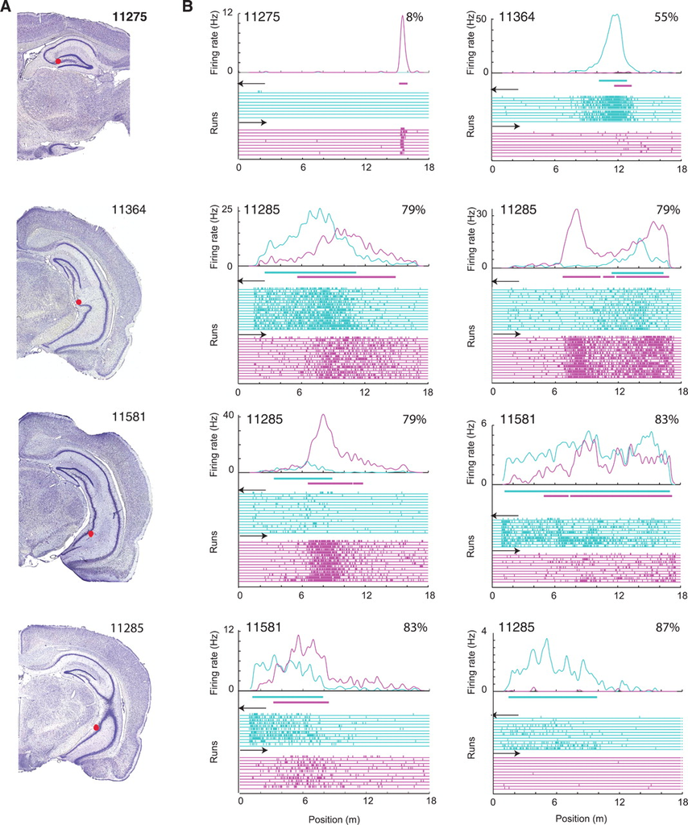

[(Kjelstrup et al. 2008)](http://dx.doi.org/10.1126/science.1157086)

## Human analogue – [(Maguire et al. 2000)](http://dx.doi.org/10.1073/pnas.070039597)

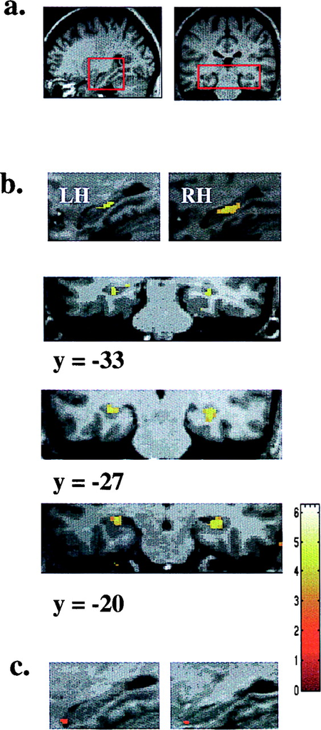

[(Maguire et al. 2000)](http://dx.doi.org/10.1073/pnas.070039597)

## [(Maguire et al. 2000)](http://dx.doi.org/10.1073/pnas.070039597)

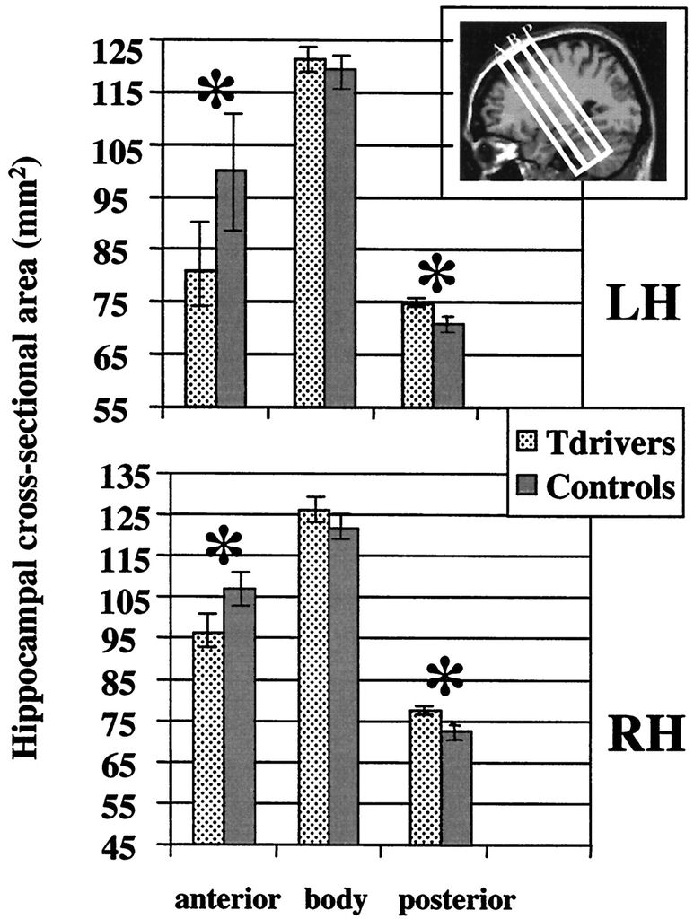

[(Maguire et al. 2000)](http://dx.doi.org/10.1073/pnas.070039597)

## [(Maguire et al. 2000)](http://dx.doi.org/10.1073/pnas.070039597)

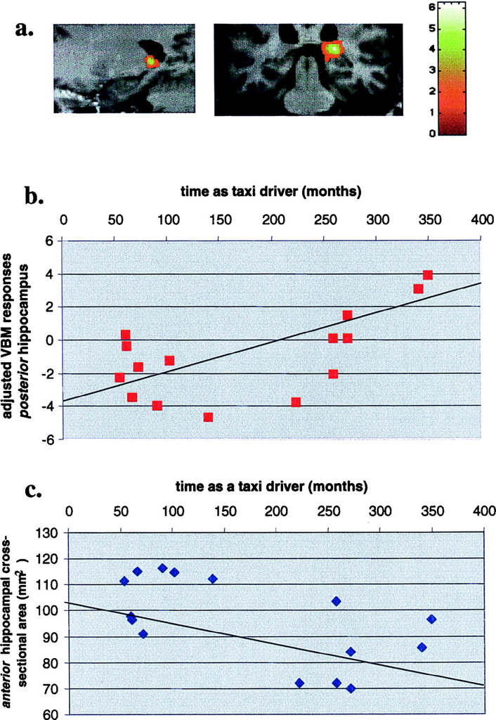

[(Maguire et al. 2000)](http://dx.doi.org/10.1073/pnas.070039597)

## Hippocampal volume in food-caching birds

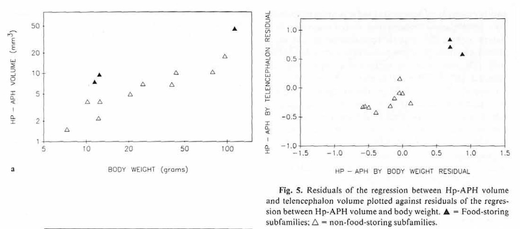

[(Sherry et al. 1989)](http://dx.doi.org/10.1159/000116516)

## Main points

- Hippocampus "hub" in brain's storage of specific information about places, events, facts
- Damage to hippocampus or medial temporal lobe (MTL) region can impair formation of new memories

## References

Battaglia, Francesco P., Karim Benchenane, Anton Sirota, Cyriel M. A. Pennartz, and Sidney I. Wiener. 2011. “The Hippocampus: Hub of Brain Network Communication for Memory.” *Trends in Cognitive Sciences* 15 (7): 310–18. doi:10.1016/j.tics.2011.05.008.

Burns, Alistair, and Steve Iliffe. 2009. “Alzheimer’s Disease.” *BMJ* 338 (February): b158. doi:10.1136/bmj.b158.

Kaufman, Adam C., Santiago V. Salazar, Laura T. Haas, Jinhee Yang, Mikhail A. Kostylev, Amanda T. Jeng, Sophie A. Robinson, et al. 2015. “Fyn Inhibition Rescues Established Memory and Synapse Loss in Alzheimer Mice.” *Annals of Neurology* 77 (6): 953–71. doi:10.1002/ana.24394.

Kjelstrup, Kirsten Brun, Trygve Solstad, Vegard Heimly Brun, Torkel Hafting, Stefan Leutgeb, Menno P. Witter, Edvard I. Moser, and May-Britt Moser. 2008. “Finite Scale of Spatial Representation in the Hippocampus.” *Science* 321 (5885): 140–43. doi:10.1126/science.1157086.

Maguire, Eleanor A, David G Gadian, Ingrid S Johnsrude, Catriona D Good, John Ashburner, Richard SJ Frackowiak, and Christopher D Frith. 2000. “Navigation-Related Structural Change in the Hippocampi of Taxi Drivers.” *Proceedings of the National Academy of Sciences* 97 (8). National Acad Sciences: 4398–4403. doi:10.1073/pnas.070039597.

Sherry, David F., Anthony L. Vaccarino, Karen Buckenham, and Rachel S. Herz. 1989. “The Hippocampal Complex of Food-Storing Birds.” *Brain, Behavior and Evolution* 34 (5): 308–17. doi:10.1159/000116516.

Squire, Larry R. 2004. “Memory Systems of the Brain: A Brief History and Current Perspective.” *Neurobiology of Learning and Memory*, Multiple Memory Systems, 82 (3): 171–77. doi:10.1016/j.nlm.2004.06.005.